# Assignment 6

Yerin Jung

7/2/2018

# 1 Feature Engineering

In addition to the features that were already created (features regarding `Max` ratio),  
I will create `Median` ratio features, since I believe it could be a better way to detect outliers than `Mean` ratio features.

```r
#setwd("/Users/Jung-yerin/Desktop/SUMMER_2018/AD/Week6")
ccard <- read_csv("purchase_credit_card.csv")
```

After changing the column names, I will filter the rows that have amount less than 0, since our goal is to detect frauds.

```r
colnames(ccard)<-c('Year_Month', 'Agency_Number', 'Agency_Name', 'Cardholder_Last_Name',
      'Cardholder_First_Initial', 'Description', 'Amount', 'Vendor', 'Transaction_Date',
      'Posted_Date', 'Merchant_Category')

# Filtering the Amount column
ccard <- ccard %>%filter(Amount>0)
```

```r
# Calculate the average amount by agency_name and merchant category
avg_agency <- ccard %>% group_by(Agency_Name, Merchant_Category) %>%
       summarise( mean_category_amount = mean(Amount),
                  mean_count_trans =n(),
                  median_category_amount = median(Amount)
                )
```

As I mentioned earlier, I will create features to create `max_ratios`, and `median_ratios` later as follows.

| Agency_Name | Merchant_Category | Year_Month | max_amount_ratio | mean_amount_ratio | median_amount_ratio | mean_count_ratio |
| --- | --- | --- | --- | --- | --- | --- |
| ARDMORE HIGHER EDUCATION CENTER | BUSINESS SERVICES NOT ELSEWHERE CLASSIFIED | 201311 | 1.0000000 | 1.0000000 | 1.0000000 | 1.0000000 |
| ARDMORE HIGHER EDUCATION CENTER | CATALOG MERCHANTS | 201308 | 2.5277395 | 2.1642043 | 2.5277395 | 0.2500000 |
| ARDMORE HIGHER EDUCATION CENTER | CATALOG MERCHANTS | 201310 | 1.2638697 | 1.0821022 | 1.2638697 | 0.2500000 |
| ARDMORE HIGHER EDUCATION CENTER | CATALOG MERCHANTS | 201311 | 0.7361303 | 0.3768468 | 0.4401481 | 0.5000000 |
| ARDMORE HIGHER EDUCATION CENTER | COMPUTER NETWORK/INFORMATION SERVICES | 201310 | 1.0000000 | 1.0000000 | 1.0000000 | 1.0000000 |
| ARDMORE HIGHER EDUCATION CENTER | DRUG STORES AND PHARMACIES | 201312 | 1.0000000 | 1.0000000 | 1.0000000 | 1.0000000 |
| ARDMORE HIGHER EDUCATION CENTER | GROCERY STORES,AND SUPERMARKETS | 201308 | 1.9589086 | 0.9747676 | 1.1798766 | 0.1818182 |
| ARDMORE HIGHER EDUCATION CENTER | GROCERY STORES,AND SUPERMARKETS | 201309 | 0.4214715 | 0.3482032 | 0.4214715 | 0.0909091 |
| ARDMORE HIGHER EDUCATION CENTER | GROCERY STORES,AND SUPERMARKETS | 201312 | 1.8513887 | 1.2128071 | 1.4680039 | 0.1818182 |
| ARDMORE HIGHER EDUCATION CENTER | GROCERY STORES,AND SUPERMARKETS | 201401 | 2.1539711 | 1.7795262 | 2.1539711 | 0.0909091 |

## 1.1 Max Ratios

The below steps and table represent feature engineering for max ratios.

```r
max_per_agency_category <- per_agency_category %>%
    mutate(Year_Month = paste("Max",Year_Month,sep="_")) %>%
    select(-mean_amount_ratio, -median_amount_ratio, -mean_count_ratio)

# Use "dcast" in Library "reshape2" to organize the data so each row is a merchant category of an agent.
max_wide <- dcast(max_per_agency_category, Agency_Name + Merchant_Category ~ Year_Month)
max_wide=as.matrix(max_wide)
max_wide[is.na(max_wide)] <-0
max_wide=as.data.frame(max_wide)
kable(head(max_wide), "html") %>%
  kable_styling((bootstrap_options = c("striped","hover")), full_width = FALSE, font_size=10)%>%
  scroll_box(height = "90%", width = "90%")
```

| Agency_Name | Merchant_Category | Max_201307 | Max_201308 | Max_201309 | Max_201310 | Max_201311 | Max_201312 | Max_201401 | Max_201402 | Max_201403 | Max_201404 | Max_201405 | Max_201406 |
| --- | --- | --- | --- | --- | --- | --- | --- | --- | --- | --- | --- | --- | --- |
| ARDMORE HIGHER EDUCATION CENTER | BUSINESS SERVICES NOT ELSEWHERE CLASSIFIED | 0 | 0 | 0 | 0 | 1.000000e+00 | 0 | 0 | 0 | 0 | 0 | 0 | 0 |
| ARDMORE HIGHER EDUCATION CENTER | CATALOG MERCHANTS | 0 | 2.527739e+00 | 0 | 1.263870e+00 | 7.361303e-01 | 0 | 0 | 0 | 0 | 0 | 0 | 0 |
| ARDMORE HIGHER EDUCATION CENTER | COMPUTER NETWORK/INFORMATION SERVICES | 0 | 0 | 0 | 1.000000e+00 | 0 | 0 | 0 | 0 | 0 | 0 | 0 | 0 |
| ARDMORE HIGHER EDUCATION CENTER | DRUG STORES AND PHARMACIES | 0 | 0 | 0 | 0 | 0 | 1.000000e+00 | 0 | 0 | 0 | 0 | 0 | 0 |
| ARDMORE HIGHER EDUCATION CENTER | GROCERY STORES,AND SUPERMARKETS | 0 | 1.958909e+00 | 0.42147150 | 0 | 0 | 1.851389e+00 | 2.153971e+00 | 0 | 0 | 0 | 0 | 0 |
| ARDMORE HIGHER EDUCATION CENTER | HARDWARE STORES | 1.000000e+00 | 0 | 0 | 0 | 0 | 0 | 0 | 0 | 0 | 0 | 0 | 0 |

## 1.2 Median Ratios

The below steps and table represent feature engineering for median ratios.

```r
median_per_agency_category <- per_agency_category %>%
    mutate(Year_Month = paste("Median",Year_Month,sep="_")) %>%
    select(-max_amount_ratio, -mean_amount_ratio, -mean_count_ratio)

# Use "dcast" in Library "reshape2" to organize the data so each row is a merchant category of an agent.
median_wide <- dcast(median_per_agency_category, Agency_Name + Merchant_Category ~ Year_Month)
median_wide=as.matrix(median_wide)
median_wide[is.na(median_wide)] <-0
median_wide=as.data.frame(median_wide)
kable(head(median_wide), "html") %>%
  kable_styling((bootstrap_options = c("striped","hover")), full_width = FALSE, font_size=10)%>%
  scroll_box(height = "90%", width = "90%")
```

| Agency_Name | Merchant_Category | Median_201307 | Median_201308 | Median_201309 | Median_201310 | Median_201311 | Median_201312 | Median_201401 | Median_201402 | Median_201403 | Median_201404 | Median_201405 | Median_201406 |
| --- | --- | --- | --- | --- | --- | --- | --- | --- | --- | --- | --- | --- | --- |
| ARDMORE HIGHER EDUCATION CENTER | BUSINESS SERVICES NOT ELSEWHERE CLASSIFIED | 0 | 0 | 0 | 0 | 1.000000000 | 0 | 0 | 0 | 0 | 0 | 0 | 0 |
| ARDMORE HIGHER EDUCATION CENTER | CATALOG MERCHANTS | 0 | 2.527739e+00 | 0 | 1.26386974 | 0.440148095 | 0 | 0 | 0 | 0 | 0 | 0 | 0 |
| ARDMORE HIGHER EDUCATION CENTER | COMPUTER NETWORK/INFORMATION SERVICES | 0 | 0 | 0 | 1.00000000 | 0 | 0 | 0 | 0 | 0 | 0 | 0 | 0 |
| ARDMORE HIGHER EDUCATION CENTER | DRUG STORES AND PHARMACIES | 0 | 0 | 0 | 0 | 0 | 1.00000000 | 0 | 0 | 0 | 0 | 0 | 0 |
| ARDMORE HIGHER EDUCATION CENTER | GROCERY STORES,AND SUPERMARKETS | 0 | 1.179877e+00 | 0.42147150 | 0 | 0 | 1.46800390 | 2.153971e+00 | 0 | 0 | 0 | 0 | 0 |
| ARDMORE HIGHER EDUCATION CENTER | HARDWARE STORES | 1.000000e+00 | 0 | 0 | 0 | 0 | 0 | 0 | 0 | 0 | 0 | 0 | 0 |

## 1.3 Final Data Frame

Finally, I joined the two data frame to perform further analyses.

```r
ccard_ready <- median_wide %>%
  left_join(max_wide, by=c('Agency_Name','Merchant_Category'))
kable(head(ccard_ready), "html") %>%
  kable_styling((bootstrap_options = c("striped","hover")), full_width = FALSE, font_size=10)%>%
  column_spec(column=c(1,2), bold = T, border_right = T, width = "2Oem", background = "skyblue") %>%
  scroll_box(height = "90%", width = "90%")
```

| Agency_Name | Merchant_Category | Median_201307 | Median_201308 | Median_201309 | Median_201310 | Median_201311 | Median_201312 | Median_201401 | Median_201402 | Median_201403 | Median_201404 | Median_201405 | Median_201406 | Max_201307 | Max_201308 | Max_201309 | Max_201310 | Max_201311 | Max_201312 | Max_201401 | Max_201402 | Max_201403 | Max_201404 | Max_201405 | Max_201406 |
| --- | --- | --- | --- | --- | --- | --- | --- | --- | --- | --- | --- | --- | --- | --- | --- | --- | --- | --- | --- | --- | --- | --- | --- | --- | --- |
| ARDMORE HIGHER EDUCATION CENTER | BUSINESS SERVICES NOT ELSEWHERE CLASSIFIED | 0 | 0 | 0 | 0 | 1.000000000 | 0 | 0 | 0 | 0 | 0 | 0 | 0 | 0 | 0 | 0 | 0 | 1.000000e+00 | 0 | 0 | 0 | 0 | 0 | 0 | 0 |
| ARDMORE HIGHER EDUCATION CENTER | CATALOG MERCHANTS | 0 | 2.527739e+00 | 0 | 1.26386974 | 0.440148095 | 0 | 0 | 0 | 0 | 0 | 0 | 0 | 0 | 2.527739e+00 | 0 | 1.263870e+00 | 7.361303e-01 | 0 | 0 | 0 | 0 | 0 | 0 | 0 |
| ARDMORE HIGHER EDUCATION CENTER | COMPUTER NETWORK/INFORMATION SERVICES | 0 | 0 | 0 | 1.00000000 | 0 | 0 | 0 | 0 | 0 | 0 | 0 | 0 | 0 | 0 | 0 | 1.000000e+00 | 0 | 0 | 0 | 0 | 0 | 0 | 0 | 0 |
| ARDMORE HIGHER EDUCATION CENTER | DRUG STORES AND PHARMACIES | 0 | 0 | 0 | 0 | 0 | 1.00000000 | 0 | 0 | 0 | 0 | 0 | 0 | 0 | 0 | 0 | 0 | 0 | 1.000000e+00 | 0 | 0 | 0 | 0 | 0 | 0 |
| ARDMORE HIGHER EDUCATION CENTER | GROCERY STORES,AND SUPERMARKETS | 0 | 1.179877e+00 | 0.42147150 | 0 | 0 | 1.46800390 | 2.153971e+00 | 0 | 0 | 0 | 0 | 0 | 0 | 1.958909e+00 | 0.42147150 | 0 | 0 | 1.851389e+00 | 2.153971e+00 | 0 | 0 | 0 | 0 | 0 |
| ARDMORE HIGHER EDUCATION CENTER | HARDWARE STORES | 1.000000e+00 | 0 | 0 | 0 | 0 | 0 | 0 | 0 | 0 | 0 | 0 | 0 | 1.000000e+00 | 0 | 0 | 0 | 0 | 0 | 0 | 0 | 0 | 0 | 0 | 0 |

# 2 PCA

Since our current dataset is a high-dimension data, I performed PCA.

```r
# Change values as numeric and remove infinite values
cols <-colnames(ccard_ready)
cols_name <- cols[3:26]
for (i in cols_name){
  ccard_ready[,i] <- as.numeric(as.character(ccard_ready[,i]))
}

is.na(ccard_ready)<-sapply(ccard_ready, is.infinite)
ccard_ready[is.na(ccard_ready)]<-0

# Dataset for PCA
pca_ready <-ccard_ready[,-c(1,2)]
kable(head(pca_ready), "html") %>%
  kable_styling((bootstrap_options = c("striped","hover")), full_width = FALSE, font_size=10)%>%
  scroll_box(height = "90%", width = "90%")
```

| Median_201307 | Median_201308 | Median_201309 | Median_201310 | Median_201311 | Median_201312 | Median_201401 | Median_201402 | Median_201403 | Median_201404 | Median_201405 | Median_201406 | Max_201307 | Max_201308 | Max_201309 | Max_201310 | Max_201311 | Max_201312 | Max_201401 | Max_201402 | Max_201403 | Max_201404 | Max_201405 | Max_201406 |
| --- | --- | --- | --- | --- | --- | --- | --- | --- | --- | --- | --- | --- | --- | --- | --- | --- | --- | --- | --- | --- | --- | --- | --- |
| 0 | 0.000000 | 0.0000000 | 0.00000 | 1.0000000 | 0.000000 | 0.000000 | 0 | 0 | 0 | 0 | 0 | 0 | 0.000000 | 0.0000000 | 0.00000 | 1.0000000 | 0.000000 | 0.000000 | 0 | 0 | 0 | 0 | 0 |
| 0 | 2.527739 | 0.0000000 | 1.26387 | 0.4401481 | 0.000000 | 0.000000 | 0 | 0 | 0 | 0 | 0 | 0 | 2.527739 | 0.0000000 | 1.26387 | 0.7361303 | 0.000000 | 0.000000 | 0 | 0 | 0 | 0 | 0 |
| 0 | 0.000000 | 0.0000000 | 1.00000 | 0.0000000 | 0.000000 | 0.000000 | 0 | 0 | 0 | 0 | 0 | 0 | 0.000000 | 0.0000000 | 1.00000 | 0.0000000 | 0.000000 | 0.000000 | 0 | 0 | 0 | 0 | 0 |
| 0 | 0.000000 | 0.0000000 | 0.00000 | 0.0000000 | 1.000000 | 0.000000 | 0 | 0 | 0 | 0 | 0 | 0 | 0.000000 | 0.0000000 | 0.00000 | 0.0000000 | 1.000000 | 0.000000 | 0 | 0 | 0 | 0 | 0 |
| 0 | 1.179877 | 0.4214715 | 0.00000 | 0.0000000 | 1.468004 | 2.153971 | 0 | 0 | 0 | 0 | 0 | 0 | 1.958909 | 0.4214715 | 0.00000 | 0.0000000 | 1.851389 | 2.153971 | 0 | 0 | 0 | 0 | 0 |
| 1 | 0.000000 | 0.0000000 | 0.00000 | 0.0000000 | 0.000000 | 0.000000 | 0 | 0 | 0 | 0 | 0 | 1 | 0.000000 | 0.0000000 | 0.00000 | 0.0000000 | 0.000000 | 0.000000 | 0 | 0 | 0 | 0 | 0 |

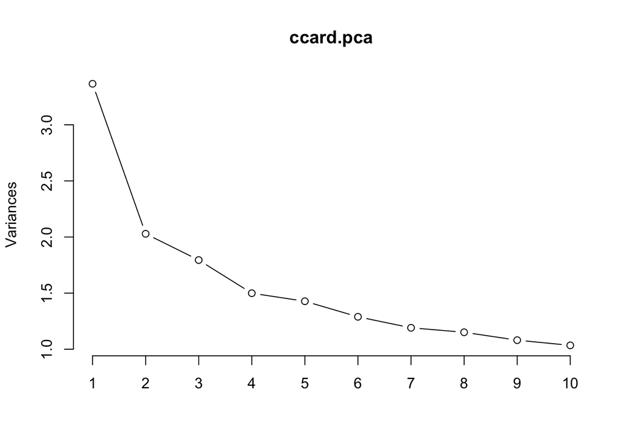

```r
# Perform PCA
ccard.pca <- prcomp(pca_ready, scale = TRUE)

# Plot PCA
plot(ccard.pca, type="l")
```

# 3 DBSCAN

To find outliers, I am going to use DBSCAN.  
The final goal of using DBSCAN is to identify dense regions, which can be detected by the number of objects close to a given point. [(Source)](http://www.sthda.com/english/articles/30-advanced-clustering/105-dbscan-density-based-clustering-essentials/)  
Especially, comparing to K-means, it performs better to detect arbitrary shapes.

In addition, I used only two variables from the `PCA` result, to plot the outcome clusters.

In the following sections, I am going to test different parameters that I can adjust in DBSCAN method.

## 3.1 EPS = 5

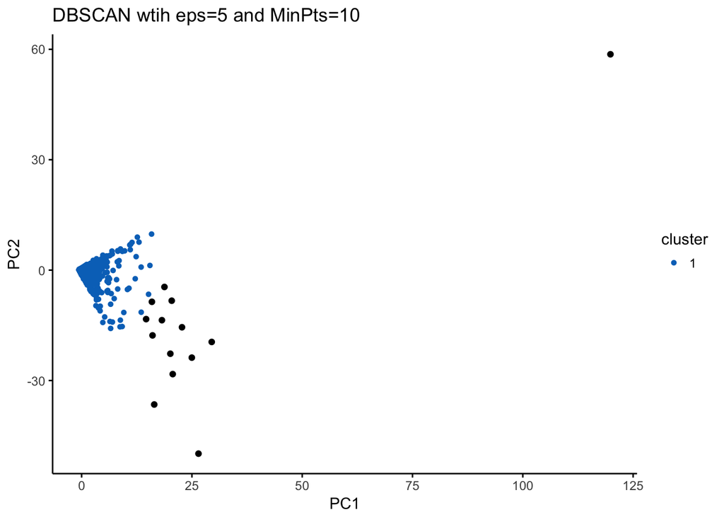

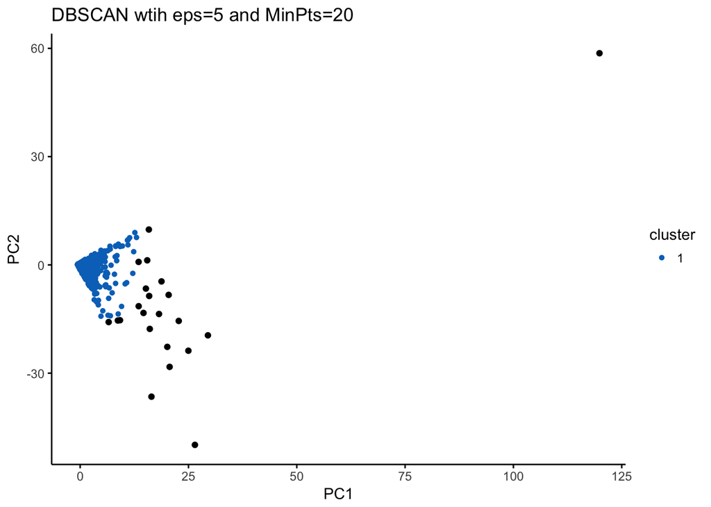

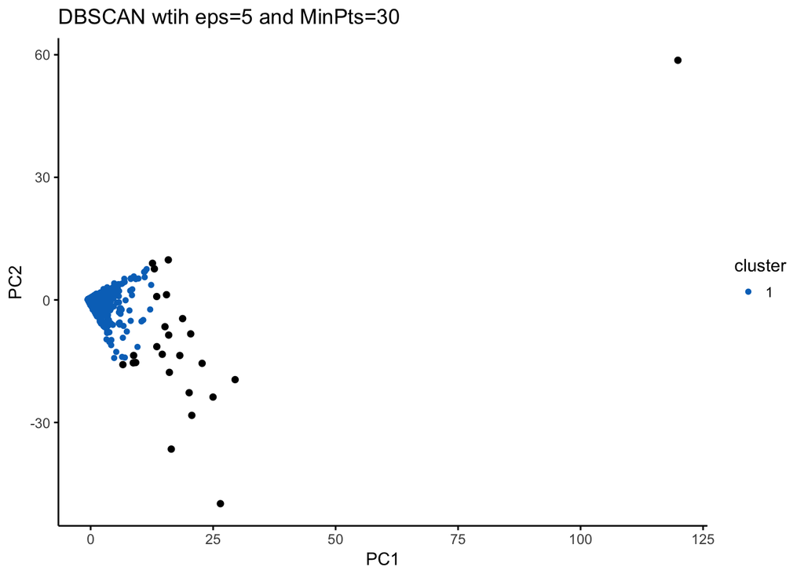

## 3.2 EPS = 10

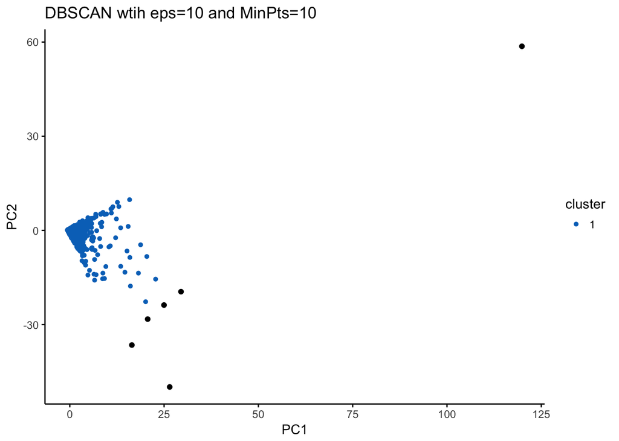

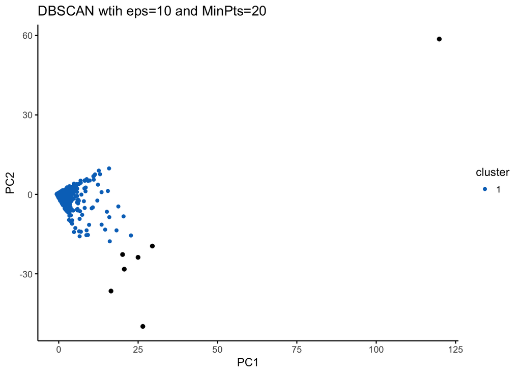

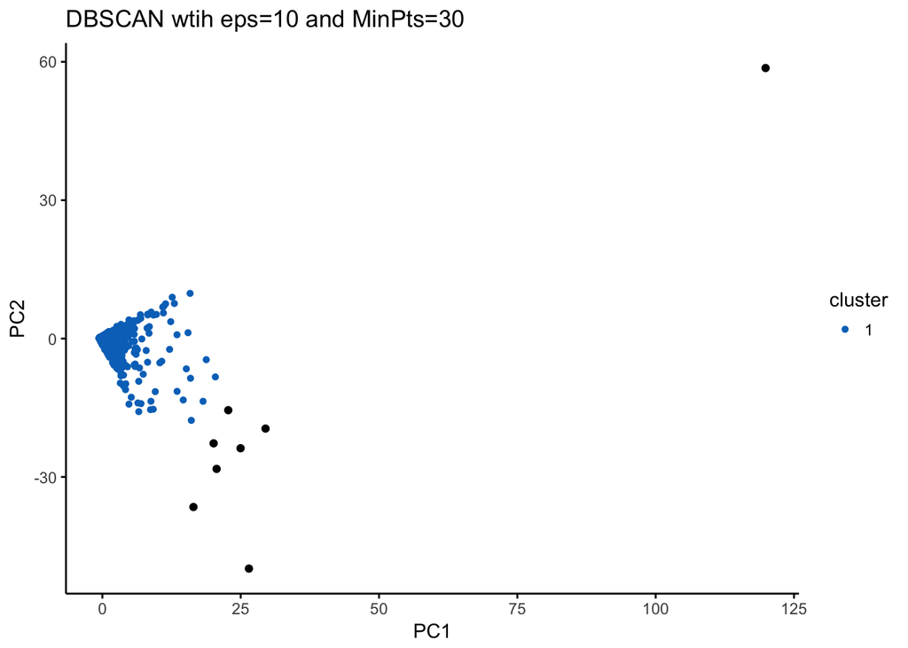

## 3.3 EPS = 15

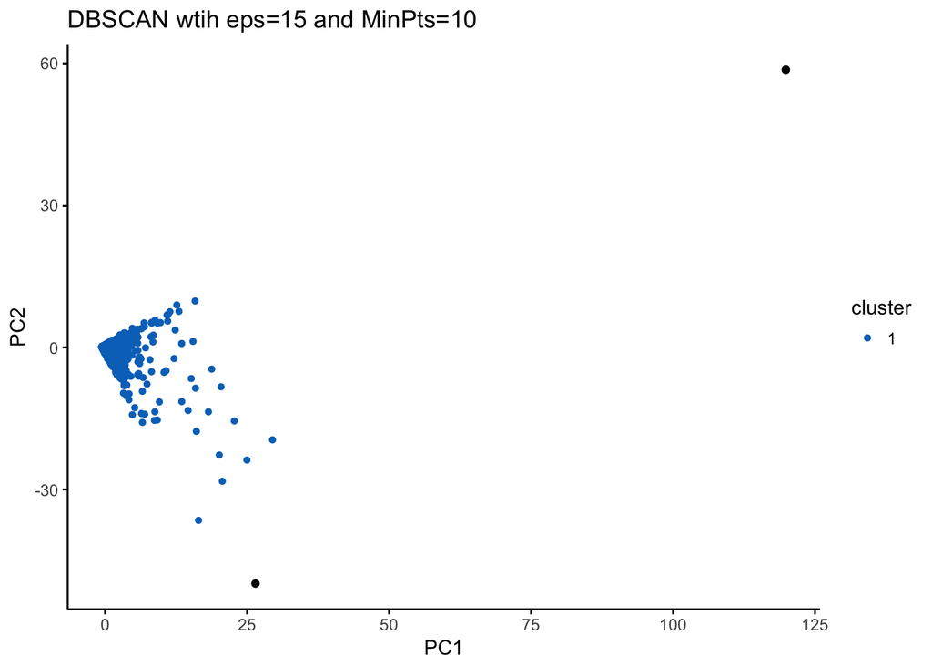

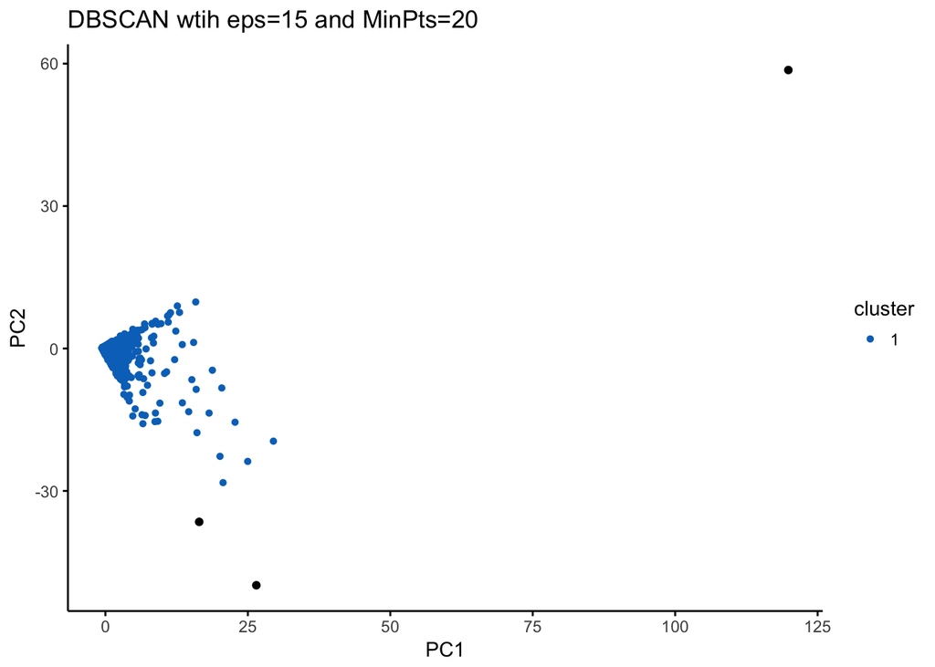

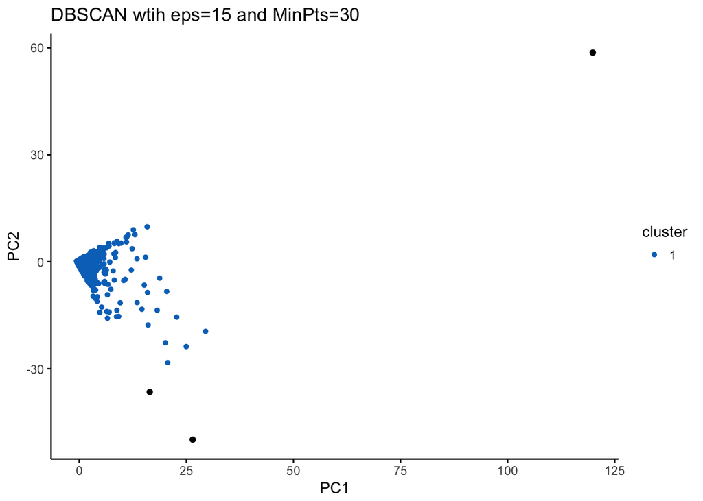

# 4 Final Results and Outliers

I have chosen `eps` to be $5$ and `MinPts` to be $20$, and plot the result as a histogram.

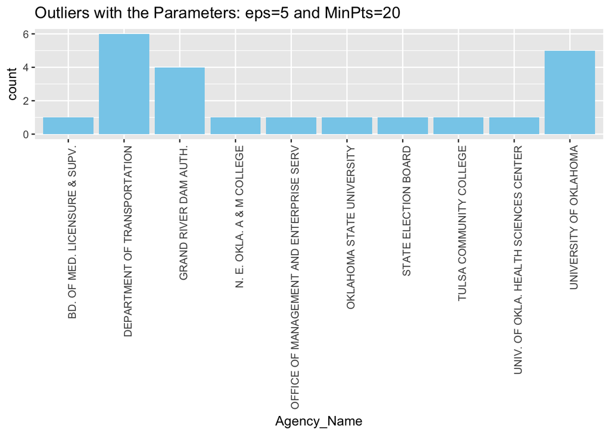

As we can see from the above plot, `DEPARTMENT OF TRANSPORTATION`, `GRAND RIVER DAM AUTH.`, and `UNIVERSITY OF OKLAHOMA` tend to have more outliers than other entities.  
Therefore, I assume that these agencies need further examination.